# Voice of Consumer data/statistics analysis: Automated vehicle Services for People with disabilities – Involved Responsive Engineering (ASPIRE Center)

Sanmi

5/9/2022

*Aim 3: Data synthesis, extrapolation, analysis and modeling:

We will synthesize the data obtained to understand the current and future needs of potential stakeholders of accessible automated transportation and services.  
This will involve presenting summary survey findings, extrapolating findings to the greater population of potential automated vehicle users, combining our data with publicly available datasets to understand factors that influence travel, displaying clusters of users based on their characteristics and needs, and ideation and development of solid models that illustrate key features and parameters for implementing automated vehicles and mobility services. *

Questions:  
What are the current transportation practices of individuals with disabilities?  
- What are the primary modes of transportation (i.e. fixed route public bus, shared, personal vehicle-passenger, personal vehicle-driver, Rideshare app (Uber or Lyft), automated vehicles, etc.)?  
- What are the usage rates for each mode of transportation?

What are the current perceptions (e.g. barriers/facilitators) of individuals with disabilities regarding accessibility of each mode of transportation?  
How often to people experience barriers with getting to where they need to go in the community for these modes of transportation? If the traveler with a disability is a parent, child, sibling, or spouse, how does that role affect accessible travel? If the travel companion of the person with a disability is a parent, child, sibling, spouses or relative how does that role affect accessible travel? How much do barriers with current modes of transportation and transportation related services (e.g. access to adaptive driving training programs, vehicle modifications, paratransit, ride share) affect access to accessible transportation?

• How much do barriers with transportation and transportation related services (e.g. access to adaptive driving training programs, vehicle modifications, paratransit, ride share) impact community participation? o How frequently do barriers with transportation and related services impact community participation for essential (e.g. medical, work, school, grocery etc.) and less essential (e.g. social and recreational events, etc.) activities and locations ASPIRE Center Page | 11 o What are the primary reasons for these problems (e.g. too costly, scheduling inconveniences, unreliable, unsafe, requires specialized equipment/adaptations, unable to accommodate additional travelers (spouse, child, service animal, attendant) • What are the anticipated barriers/facilitators to using automated vehicles for transportation? o What vehicle features or services would be needed to make automated vehicles accessible? o What potential impact (influence) could accessible automated vehicles have on community participation?

Function to estimate fisher exact test and load packages

```r
rm(list = ls())
pack<-function(x){
  for (i in x){
    if (!require(i,character.only = T)){
      install.packages(i,dependencies = T,repos="https://cran.rstudio.com")
      require(i,character.only = T)
    }
  }
}

pvalue <- function(x, ...) {
    # Construct vectors of data y, and groups (strata) g
    y <- unlist(x)
    g <- factor(rep(1:length(x), times=sapply(x, length)))
    #if (is.numeric(y)) {
    #    # For numeric variables, perform a standard 2-sample t-test
    #    p <- t.test(y ~ g)$p.value
    #} else
      {
        # For categorical variables, perform a chi-squared test of independence
        p <- fisher.test(table(y, g),simulate.p.value = T)$p.value
    }
    # Format the p-value, using an HTML entity for the less-than sign.
    # The initial empty string places the output on the line below the variable label.
    c("", sub("<", "&lt;", format.pval(p, digits=3, eps=0.001)))
}

pack(c("readr","dplyr","tidyr","ggplot2", "lubridate","gtsummary","stringr","readxl","tidyr","kableExtra","table1","broom"))
pack("table1")
pack("DT")
```

Load files and create data/labels dictionary

```r
dataf <- read_excel("Clean_VoC_April_DATA.xlsx")
data_labels <- read_excel("Cleaned_VoC_April_DATA_LABELS.xlsx")
state_census<- read_csv("state census - Sheet1.csv")
labs<-colnames(data_labels)
colnames(data_labels)<-colnames(dataf)
dataf<-data_labels
dataf<-dataf[order(dataf$fwat_id),]

dataf<-dataf[c(1:450),]
#write_csv(dataf, "voc_sorted.csv")
#dataf_consent<-dataf%>%
#  filter(consent_y_n=="Yes")

#dataf_complete<-dataf%>%
#  filter(dataf$consent_y_n==1)%>%
#  filter(working_automated_vehicle_services_for_people_with_timestamp!="[not completed]")
#write_csv(dataf_complete, "voc_complete_consent.csv")

data.dict<-data.frame(labels=colnames(dataf),surveyq=labs)
```

# Data dictionary

```r
datatable(data.dict)
```

|  | labels | surveyq |
| --- | --- | --- |
| 1 | fwat_id | Record ID |
| 2 | working_automated_vehicle_services_for_people_with_timestamp | Survey Timestamp |
| 3 | consent_y_n | This survey is for the Voice of the Consumer Department of Transportation (VOCDOT) research study in which we aim to collect information and opinions directly from individuals living in the United Sta… |
| 4 | dpct | Please choose the answer which best describes you for survey purposes. If you are a person with dual roles, please choose first the role you most associate yourself with. Feel free to take the survey … |
| 5 | person_w_disabilty___1 | Please identify your disability. Check all that apply (choice=Hearing difficulty, deaf or having serious difficulty hearing (DEAR).) |
| 6 | person_w_disabilty___2 | Please identify your disability. Check all that apply (choice=Vision difficulty, blind or having serious difficulty seeing, even when wearing glasses (DEYE).) |
| 7 | person_w_disabilty___3 | Please identify your disability. Check all that apply (choice=Cognitive difficulty. Because of a physical, mental, or emotional problem, having difficulty remembering, concentrating, or making decisio… |
| 8 | person_w_disabilty___4 | Please identify your disability. Check all that apply (choice=Ambulatory difficulty. Having serious difficulty walking or climbing stairs (DPHY).) |
| 9 | person_w_disabilty___5 | Please identify your disability. Check all that apply (choice=Self-care difficulty. Having difficulty bathing or dressing (DDRS).) |
| 10 | person_w_disabilty___6 | Please identify your disability. Check all that apply (choice=Independent living difficulty. Because of a physical, mental, or emotional problem, having difficulty doing errands alone such as visiting… |

[output cut: 188 more lines]

```r
#reported conditions
```

Classify states into regions

```r
#
Northeast<-c("Connecticut",
"Maine",
"Massachusetts",
"New Hampshire",
"Rhode Island",
"Vermont",
"New Jersey",
"New York",
"Pennsylvania")

Midwest<-c("Indiana",
"Illinois",
"Michigan",
"Ohio",
"Wisconsin",
"Iowa",
"Nebraska",
"Kansas",
"North Dakota",
"Minnesota",
"South Dakota",
"Missouri")

South<-c("Arkansas",
"Louisiana",
"Oklahoma",
"Texas",
"Alabama",
"Kentucky",
"Mississippi",
"Tennessee",
"Delaware",
"District of Columbia",
"Florida",
"Georgia",
"Maryland",
"North Carolina",
"South Carolina",
"Virginia",
"West Virginia")


West<-c("Alaska",
"California",
"Hawaii",
"Oregon",
"Washington",

"Montana",
"Utah",
"Nevada",
"Wyoming",
"Arizona",
"Colorado",
"Idaho",
"New Mexico")

#loop to replace the participant entered state with regions and divisions
dataf$regions<-NA
dataf$divisions<-NA
for (i in 1:nrow(dataf)){
  for (j in 1:nrow(state_census)){
    if((dataf$state[i] == state_census$`State Code`[j])&
       !is.na(dataf$state[i])){
      dataf$regions[i]<-state_census$Region[j]
      dataf$divisions[i]<-state_census$Division[j]
    }
    else if (is.na(dataf$state[i])){
      dataf$regions[i]<-NA
      dataf$divisions[i]<-NA}
  }
}

#confirm replacement
dataf%>%
  select(state,regions,divisions)
```

```
## # A tibble: 450 × 3
##    state regions   divisions
##    <chr> <chr>     <chr>
##  1 NJ    Northeast Middle Atlantic
##  2 <NA>  <NA>      <NA>
##  3 NJ    Northeast Middle Atlantic
##  4 <NA>  <NA>      <NA>
##  5 NJ    Northeast Middle Atlantic
##  6 PA    Northeast Middle Atlantic
##  7 PA    Northeast Middle Atlantic
##  8 <NA>  <NA>      <NA>
##  9 IN    Midwest   East North Central
## 10 <NA>  <NA>      <NA>
## # … with 440 more rows
```

Disability types

```r
disab_type<-c("Hearing difficulty",
              "Vision difficulty",
              "Cognitive difficulty",
              "Ambulatory difficulty",
              "Self-care difficulty",
              "Independent living difficulty")
discol<-c(5:10)

for (i in 1:nrow(dataf)){
  for (j in discol){
    if (dataf[i,j]=="Checked"){dataf$disab_type[i]<-disab_type[j-4]}
    }
  }
```

Explore raw distribution of demographic characteristics

```r
table1(~ ethnicity+race+gender+age+marit_stat+education+time_living_disability+regions+divisions+
         connect_transpo+comfortable_av+price_range+hous_sit+
         employment+income+veteran | disab_type,data = dataf,rowlabelhead = "Characteristics by disability type")
```

| Characteristics by disability type | Ambulatory difficulty (N=146) | Cognitive difficulty (N=138) | Hearing difficulty (N=8) | Independent living difficulty (N=101) | Self-care difficulty (N=30) | Vision difficulty (N=27) | Overall (N=450) |
| --- | --- | --- | --- | --- | --- | --- | --- |
| ethnicity |  |  |  |  |  |  |  |
| Hispanic or Latino | 7 (4.8%) | 10 (7.2%) | 1 (12.5%) | 8 (7.9%) | 5 (16.7%) | 6 (22.2%) | 37 (8.2%) |
| Not Hispanic or Latino | 108 (74.0%) | 54 (39.1%) | 5 (62.5%) | 76 (75.2%) | 21 (70.0%) | 16 (59.3%) | 280 (62.2%) |
| Prefer not to answer | 11 (7.5%) | 9 (6.5%) | 0 (0%) | 9 (8.9%) | 3 (10.0%) | 2 (7.4%) | 34 (7.6%) |
| Missing | 20 (13.7%) | 65 (47.1%) | 2 (25.0%) | 8 (7.9%) | 1 (3.3%) | 3 (11.1%) | 99 (22.0%) |
| race |  |  |  |  |  |  |  |
| Asian | 7 (4.8%) | 3 (2.2%) | 0 (0%) | 2 (2.0%) | 1 (3.3%) | 1 (3.7%) | 14 (3.1%) |
| Black or African American | 15 (10.3%) | 6 (4.3%) | 1 (12.5%) | 11 (10.9%) | 1 (3.3%) | 2 (7.4%) | 36 (8.0%) |
| Other (Please specify below.) | 1 (0.7%) | 1 (0.7%) | 0 (0%) | 1 (1.0%) | 0 (0%) | 0 (0%) | 3 (0.7%) |
| Prefer not to answer | 9 (6.2%) | 6 (4.3%) | 0 (0%) | 8 (7.9%) | 0 (0%) | 2 (7.4%) | 25 (5.6%) |
| Two or more races | 4 (2.7%) | 1 (0.7%) | 1 (12.5%) | 1 (1.0%) | 2 (6.7%) | 0 (0%) | 9 (2.0%) |
| White or Caucasian | 90 (61.6%) | 52 (37.7%) | 4 (50.0%) | 69 (68.3%) | 23 (76.7%) | 17 (63.0%) | 255 (56.7%) |
| American Indian or Alaskan Native | 0 (0%) | 2 (1.4%) | 0 (0%) | 1 (1.0%) | 0 (0%) | 2 (7.4%) | 5 (1.1%) |
| Native Hawaiian or other Pacific Islander | 0 (0%) | 2 (1.4%) | 0 (0%) | 0 (0%) | 2 (6.7%) | 0 (0%) | 4 (0.9%) |
| Missing | 20 (13.7%) | 65 (47.1%) | 2 (25.0%) | 8 (7.9%) | 1 (3.3%) | 3 (11.1%) | 99 (22.0%) |
| gender |  |  |  |  |  |  |  |
| Female | 45 (30.8%) | 44 (31.9%) | 4 (50.0%) | 60 (59.4%) | 12 (40.0%) | 11 (40.7%) | 176 (39.1%) |
| Male | 77 (52.7%) | 24 (17.4%) | 2 (25.0%) | 31 (30.7%) | 14 (46.7%) | 11 (40.7%) | 159 (35.3%) |
| Non-binary/third gender | 3 (2.1%) | 2 (1.4%) | 0 (0%) | 0 (0%) | 2 (6.7%) | 1 (3.7%) | 8 (1.8%) |
| Prefer not to answer | 1 (0.7%) | 2 (1.4%) | 0 (0%) | 2 (2.0%) | 1 (3.3%) | 0 (0%) | 6 (1.3%) |
| Transgender: Female to Male | 0 (0%) | 1 (0.7%) | 0 (0%) | 0 (0%) | 0 (0%) | 0 (0%) | 1 (0.2%) |
| Transgender: Male to Female | 0 (0%) | 0 (0%) | 0 (0%) | 0 (0%) | 0 (0%) | 1 (3.7%) | 1 (0.2%) |
| Missing | 20 (13.7%) | 65 (47.1%) | 2 (25.0%) | 8 (7.9%) | 1 (3.3%) | 3 (11.1%) | 99 (22.0%) |
| age |  |  |  |  |  |  |  |
| 18-24 | 2 (1.4%) | 2 (1.4%) | 0 (0%) | 6 (5.9%) | 0 (0%) | 3 (11.1%) | 13 (2.9%) |
| 25-34 | 15 (10.3%) | 21 (15.2%) | 4 (50.0%) | 12 (11.9%) | 5 (16.7%) | 3 (11.1%) | 60 (13.3%) |
| 35-44 | 23 (15.8%) | 12 (8.7%) | 1 (12.5%) | 14 (13.9%) | 9 (30.0%) | 4 (14.8%) | 63 (14.0%) |
| 45-54 | 12 (8.2%) | 13 (9.4%) | 0 (0%) | 22 (21.8%) | 5 (16.7%) | 4 (14.8%) | 56 (12.4%) |
| 55-64 | 31 (21.2%) | 9 (6.5%) | 1 (12.5%) | 24 (23.8%) | 3 (10.0%) | 3 (11.1%) | 71 (15.8%) |
| 65-74 | 32 (21.9%) | 14 (10.1%) | 0 (0%) | 11 (10.9%) | 5 (16.7%) | 7 (25.9%) | 69 (15.3%) |

[output cut: 103 more lines]

Race and ethnicity into 1

```r
#Race and ethnicity into 1
```

Gender into 3

```r
#Gender into male, female, others
```

Education into some high-school, high-school, post-high-school, advanced deg

```r
#Education into Education into some high-school, high-school, post-high-school, advanced deg
```

# Demographic characteristics

```r
#state+
#+occupation
table1(~ ethnicity+race+gender+age+marit_stat+education+time_living_disability+regions+divisions+
         connect_transpo+comfortable_av+price_range+hous_sit+
         employment+income+veteran | disab_type,data = dataf,rowlabelhead = "Characteristics by disability type")
```

| Characteristics by disability type | Ambulatory difficulty (N=146) | Cognitive difficulty (N=138) | Hearing difficulty (N=8) | Independent living difficulty (N=101) | Self-care difficulty (N=30) | Vision difficulty (N=27) | Overall (N=450) |
| --- | --- | --- | --- | --- | --- | --- | --- |
| ethnicity |  |  |  |  |  |  |  |
| Hispanic or Latino | 7 (4.8%) | 10 (7.2%) | 1 (12.5%) | 8 (7.9%) | 5 (16.7%) | 6 (22.2%) | 37 (8.2%) |
| Not Hispanic or Latino | 108 (74.0%) | 54 (39.1%) | 5 (62.5%) | 76 (75.2%) | 21 (70.0%) | 16 (59.3%) | 280 (62.2%) |
| Prefer not to answer | 11 (7.5%) | 9 (6.5%) | 0 (0%) | 9 (8.9%) | 3 (10.0%) | 2 (7.4%) | 34 (7.6%) |
| Missing | 20 (13.7%) | 65 (47.1%) | 2 (25.0%) | 8 (7.9%) | 1 (3.3%) | 3 (11.1%) | 99 (22.0%) |
| race |  |  |  |  |  |  |  |
| Asian | 7 (4.8%) | 3 (2.2%) | 0 (0%) | 2 (2.0%) | 1 (3.3%) | 1 (3.7%) | 14 (3.1%) |
| Black or African American | 15 (10.3%) | 6 (4.3%) | 1 (12.5%) | 11 (10.9%) | 1 (3.3%) | 2 (7.4%) | 36 (8.0%) |
| Other (Please specify below.) | 1 (0.7%) | 1 (0.7%) | 0 (0%) | 1 (1.0%) | 0 (0%) | 0 (0%) | 3 (0.7%) |
| Prefer not to answer | 9 (6.2%) | 6 (4.3%) | 0 (0%) | 8 (7.9%) | 0 (0%) | 2 (7.4%) | 25 (5.6%) |
| Two or more races | 4 (2.7%) | 1 (0.7%) | 1 (12.5%) | 1 (1.0%) | 2 (6.7%) | 0 (0%) | 9 (2.0%) |
| White or Caucasian | 90 (61.6%) | 52 (37.7%) | 4 (50.0%) | 69 (68.3%) | 23 (76.7%) | 17 (63.0%) | 255 (56.7%) |
| American Indian or Alaskan Native | 0 (0%) | 2 (1.4%) | 0 (0%) | 1 (1.0%) | 0 (0%) | 2 (7.4%) | 5 (1.1%) |
| Native Hawaiian or other Pacific Islander | 0 (0%) | 2 (1.4%) | 0 (0%) | 0 (0%) | 2 (6.7%) | 0 (0%) | 4 (0.9%) |
| Missing | 20 (13.7%) | 65 (47.1%) | 2 (25.0%) | 8 (7.9%) | 1 (3.3%) | 3 (11.1%) | 99 (22.0%) |
| gender |  |  |  |  |  |  |  |
| Female | 45 (30.8%) | 44 (31.9%) | 4 (50.0%) | 60 (59.4%) | 12 (40.0%) | 11 (40.7%) | 176 (39.1%) |
| Male | 77 (52.7%) | 24 (17.4%) | 2 (25.0%) | 31 (30.7%) | 14 (46.7%) | 11 (40.7%) | 159 (35.3%) |
| Non-binary/third gender | 3 (2.1%) | 2 (1.4%) | 0 (0%) | 0 (0%) | 2 (6.7%) | 1 (3.7%) | 8 (1.8%) |
| Prefer not to answer | 1 (0.7%) | 2 (1.4%) | 0 (0%) | 2 (2.0%) | 1 (3.3%) | 0 (0%) | 6 (1.3%) |
| Transgender: Female to Male | 0 (0%) | 1 (0.7%) | 0 (0%) | 0 (0%) | 0 (0%) | 0 (0%) | 1 (0.2%) |
| Transgender: Male to Female | 0 (0%) | 0 (0%) | 0 (0%) | 0 (0%) | 0 (0%) | 1 (3.7%) | 1 (0.2%) |
| Missing | 20 (13.7%) | 65 (47.1%) | 2 (25.0%) | 8 (7.9%) | 1 (3.3%) | 3 (11.1%) | 99 (22.0%) |
| age |  |  |  |  |  |  |  |
| 18-24 | 2 (1.4%) | 2 (1.4%) | 0 (0%) | 6 (5.9%) | 0 (0%) | 3 (11.1%) | 13 (2.9%) |
| 25-34 | 15 (10.3%) | 21 (15.2%) | 4 (50.0%) | 12 (11.9%) | 5 (16.7%) | 3 (11.1%) | 60 (13.3%) |
| 35-44 | 23 (15.8%) | 12 (8.7%) | 1 (12.5%) | 14 (13.9%) | 9 (30.0%) | 4 (14.8%) | 63 (14.0%) |
| 45-54 | 12 (8.2%) | 13 (9.4%) | 0 (0%) | 22 (21.8%) | 5 (16.7%) | 4 (14.8%) | 56 (12.4%) |
| 55-64 | 31 (21.2%) | 9 (6.5%) | 1 (12.5%) | 24 (23.8%) | 3 (10.0%) | 3 (11.1%) | 71 (15.8%) |
| 65-74 | 32 (21.9%) | 14 (10.1%) | 0 (0%) | 11 (10.9%) | 5 (16.7%) | 7 (25.9%) | 69 (15.3%) |

[output cut: 103 more lines]

Write function to summarize multiple choice questions

```r
domulti_sum<-function(df){
    datalist=list()
for (i in 1:ncol(df)){
  dat<-data.frame(
    n=table(df[,i])["Checked"],
    percent=((table(df[,i])["Checked"])/nrow(df))*100,
    row.names = colnames(df)[i]) # maybe you want to keep track of which iteration produced it?
  datalist[[i]] <- dat # add it to your list
}
    big_data = do.call(rbind, datalist)
 #   big_data<-big_data%>%
#      mutate('n (%)'=paste(n,"(",percent,")"))
    return(big_data)
  }
```

# Responses’ Summary

```r
#transport modes
transport_modes<-domulti_sum(dataf[,14:21])
datatable(transport_modes)
```

|  | n | percent |
| --- | --- | --- |
| transpo_modes___1 | 162 | 36 |
| transpo_modes___2 | 155 | 34.4444444444444 |
| transpo_modes___3 | 156 | 34.6666666666667 |
| transpo_modes___4 | 81 | 18 |
| transpo_modes___5 | 89 | 19.7777777777778 |
| transpo_modes___6 | 39 | 8.66666666666667 |
| transpo_modes___7 | 22 | 4.88888888888889 |
| other_transpo_mode |  |  |

```r
rownames(transport_modes)<-c("Licensed Driver or Permit holder of a Personally Owned or Leased Vehicle",
                        "Passenger of a Personally Owned or Leased Vehicle",
                        "Ground Public Transportation (e.g., paratransit, fixed route bus, train, subway, etc.)",
                        "Ground Private Transportation (e.g., Uber, Lyft, Taxi)",
                        "Light rail or train air taxi (flying vehicles or drones)",
                        "Air travel (e.g., planes, helicopters)",
                        "Water travel (e.g., boat, ferry, water taxi)",
                        "Others")
datatable(transport_modes)
```

|  | n | percent |
| --- | --- | --- |
| Licensed Driver or Permit holder of a Personally Owned or Leased Vehicle | 162 | 36 |
| Passenger of a Personally Owned or Leased Vehicle | 155 | 34.4444444444444 |
| Ground Public Transportation (e.g., paratransit, fixed route bus, train, subway, etc.) | 156 | 34.6666666666667 |
| Ground Private Transportation (e.g., Uber, Lyft, Taxi) | 81 | 18 |
| Light rail or train air taxi (flying vehicles or drones) | 89 | 19.7777777777778 |
| Air travel (e.g., planes, helicopters) | 39 | 8.66666666666667 |
| Water travel (e.g., boat, ferry, water taxi) | 22 | 4.88888888888889 |
| Others |  |  |

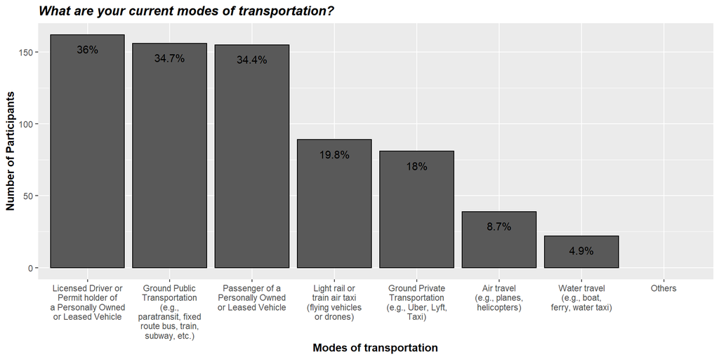

```r
transport_modes%>%
  mutate(x=rownames(transport_modes),
         percent=paste(round(percent,1),"%",sep = ""))%>%
  ggplot(aes(x=reorder(x,-n), y=n,label=percent))+
  geom_bar(stat="identity", color="black")+
  geom_text(nudge_y = -10)+
  xlab("Modes of transportation") +
  ylab("Number of Participants") +
  ggtitle(str_wrap("What are your current modes of transportation?",70))+
  scale_fill_manual(values = "#E63F00")+
  scale_x_discrete(labels = function(x) str_wrap(x, width = 18))+
  theme(
    plot.title = element_text(face="bold.italic"),
    axis.title.x = element_text(face="bold"),
    axis.title.y = element_text(face="bold"))
```

### Vehicles you would be willing to use:

```r
#av systems
av_systems<-domulti_sum(dataf[,22:27])


rownames(av_systems)<-c("Full-size buses",
                        "Mini-buses or multi-passenger van ride-share",
                        "Van or mini-vans",
                        "Cars",
                        "Light rail or train air taxi (flying vehicles or drones)",
                        "Others")
datatable(av_systems)
```

|  | n | percent |
| --- | --- | --- |
| Full-size buses | 126 | 28 |
| Mini-buses or multi-passenger van ride-share | 181 | 40.2222222222222 |
| Van or mini-vans | 224 | 49.7777777777778 |
| Cars | 216 | 48 |
| Light rail or train air taxi (flying vehicles or drones) | 130 | 28.8888888888889 |
| Others | 21 | 4.66666666666667 |

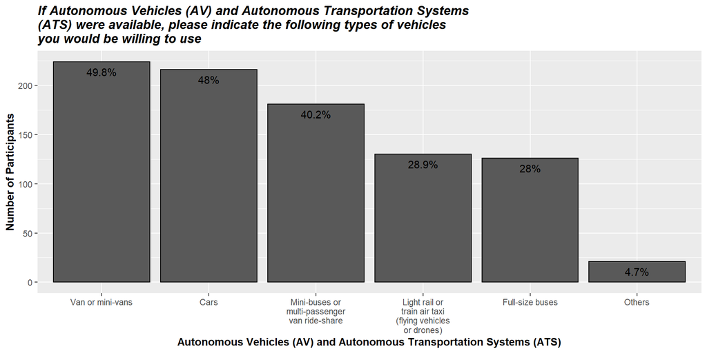

```r
av_systems%>%
  mutate(x=rownames(av_systems),
         percent=paste(round(percent,1),"%",sep = ""))%>%
  ggplot(aes(x=reorder(x,-n), y=n,label=percent))+
  geom_bar(stat="identity", color="black")+
  geom_text(nudge_y = -10)+
  xlab("Autonomous Vehicles (AV) and Autonomous Transportation Systems (ATS)") +
  ylab("Number of Participants") +
  ggtitle(str_wrap("If Autonomous Vehicles (AV) and Autonomous Transportation Systems (ATS) were available, please indicate the following types of vehicles you would be willing to use",70))+
  scale_fill_manual(values = "#E63F00")+
  scale_x_discrete(labels = function(x) str_wrap(x, width = 18))+
  theme(
    plot.title = element_text(face="bold.italic"),
    axis.title.x = element_text(face="bold"),
    axis.title.y = element_text(face="bold"))
```

## Technologies you would be able to use to arrange a ride in an AV or ATS

```r
#arrg_ride_tech
arrg_ride_tech<-domulti_sum(dataf[,29:35])
datatable(arrg_ride_tech)
```

|  | n | percent |
| --- | --- | --- |
| arrg_ride_tech___1 | 289 | 64.2222222222222 |
| arrg_ride_tech___2 | 116 | 25.7777777777778 |
| arrg_ride_tech___3 | 78 | 17.3333333333333 |
| arrg_ride_tech___4 | 147 | 32.6666666666667 |
| arrg_ride_tech___5 | 210 | 46.6666666666667 |
| arrg_ride_tech___7 | 7 | 1.55555555555556 |
| arrg_ride_tech___8 | 9 | 2 |

## Methods you would be willing to use to arrange a ride in an AV or ATS

```r
#meth_arrg_ride___1
meth_arrg_ride<-domulti_sum(dataf[,37:43])
datatable(meth_arrg_ride)
```

|  | n | percent |
| --- | --- | --- |
| meth_arrg_ride___1 | 263 | 58.4444444444444 |
| meth_arrg_ride___2 | 206 | 45.7777777777778 |
| meth_arrg_ride___3 | 198 | 44 |
| meth_arrg_ride___4 | 210 | 46.6666666666667 |
| meth_arrg_ride___5 | 128 | 28.4444444444444 |
| meth_arrg_ride___6 | 110 | 24.4444444444444 |
| meth_arrg_ride___7 | 10 | 2.22222222222222 |

## Activities you would use AV or ATS to access

```r
#activities_access___1
activities_access<-domulti_sum(dataf[,45:51])
datatable(activities_access)
```

|  | n | percent |
| --- | --- | --- |
| activities_access___1 | 270 | 60 |
| activities_access___2 | 220 | 48.8888888888889 |
| activities_access___3 | 143 | 31.7777777777778 |
| activities_access___4 | 216 | 48 |
| activities_access___5 | 217 | 48.2222222222222 |
| activities_access___6 | 221 | 49.1111111111111 |
| activities_access___7 | 18 | 4 |

## Services you would use AV and ATS for:

```r
services_use<-domulti_sum(dataf[,53:58])
datatable(services_use)
```

|  | n | percent |
| --- | --- | --- |
| services_use___1 | 284 | 63.1111111111111 |
| services_use___2 | 131 | 29.1111111111111 |
| services_use___3 | 146 | 32.4444444444444 |
| services_use___4 | 109 | 24.2222222222222 |
| services_use___5 | 159 | 35.3333333333333 |
| services_use___6 | 8 | 1.77777777777778 |

## If AV and ATS were available for fixed routes (fixed schedule) similar to public bus schedules, options you would use:

```r
fixed_rte_opt<-domulti_sum(dataf[,61:65])
datatable(fixed_rte_opt)
```

|  | n | percent |
| --- | --- | --- |
| fixed_rte_opt___1 | 137 | 30.4444444444444 |
| fixed_rte_opt___2 | 224 | 49.7777777777778 |
| fixed_rte_opt___3 | 183 | 40.6666666666667 |
| fixed_rte_opt___4 | 121 | 26.8888888888889 |
| fixed_rte_opt___5 | 13 | 2.88888888888889 |

## If AV and ATS were available for custom routes (on-demand/not on a fixed schedule, customized pick-up and drop-off points), options you would use:

```r
custom_rtes<-domulti_sum(dataf[,67:71])
datatable(custom_rtes)
```

|  | n | percent |
| --- | --- | --- |
| custom_rtes___1 | 238 | 52.8888888888889 |
| custom_rtes___2 | 140 | 31.1111111111111 |
| custom_rtes___3 | 156 | 34.6666666666667 |
| custom_rtes___4 | 138 | 30.6666666666667 |
| custom_rtes___5 | 12 | 2.66666666666667 |

## Accessibility features of an AV and/or ATS you would require

```r
access_features<-domulti_sum(dataf[,73:81])
datatable(access_features)
```

|  | n | percent |
| --- | --- | --- |
| access_features___1 | 188 | 41.7777777777778 |
| access_features___2 | 191 | 42.4444444444444 |
| access_features___3 | 139 | 30.8888888888889 |
| access_features___4 | 131 | 29.1111111111111 |
| access_features___5 | 135 | 30 |
| access_features___6 | 121 | 26.8888888888889 |
| access_features___7 | 140 | 31.1111111111111 |
| access_features___8 | 170 | 37.7777777777778 |
| access_features___9 | 9 | 2 |

## What other forms of transportation would you like to be able to access using AV and ATS?

```r
other_forms_transpo<-domulti_sum(dataf[,85:92])
datatable(other_forms_transpo)
```

|  | n | percent |
| --- | --- | --- |
| other_forms_transpo___1 | 157 | 34.8888888888889 |
| other_forms_transpo___2 | 151 | 33.5555555555556 |
| other_forms_transpo___3 | 124 | 27.5555555555556 |
| other_forms_transpo___4 | 117 | 26 |
| other_forms_transpo___5 | 110 | 24.4444444444444 |
| other_forms_transpo___6 | 129 | 28.6666666666667 |
| other_forms_transpo___7 | 11 | 2.44444444444444 |
| other_forms_transpo___8 | 21 | 4.66666666666667 |

## Which of the following AV services can you see yourself using?

```r
av_services_using<-domulti_sum(dataf[,(96:102)])
datatable(av_services_using)
```

|  | n | percent |
| --- | --- | --- |
| av_services_using___1 | 148 | 32.8888888888889 |
| av_services_using___2 | 123 | 27.3333333333333 |
| av_services_using___3 | 134 | 29.7777777777778 |
| av_services_using___4 | 96 | 21.3333333333333 |
| av_services_using___5 | 217 | 48.2222222222222 |
| av_services_using___6 | 147 | 32.6666666666667 |
| av_services_using___7 | 152 | 33.7777777777778 |

## Automated or automated driver assist features would you be interested in having in vehicle:

```r
pers_vehicle_asst_feat<-domulti_sum(dataf[,104:116])
datatable(pers_vehicle_asst_feat)
```

|  | n | percent |
| --- | --- | --- |
| pers_vehicle_asst_feat___1 | 148 | 32.8888888888889 |
| pers_vehicle_asst_feat___2 | 166 | 36.8888888888889 |
| pers_vehicle_asst_feat___3 | 218 | 48.4444444444444 |
| pers_vehicle_asst_feat___4 | 206 | 45.7777777777778 |
| pers_vehicle_asst_feat___5 | 178 | 39.5555555555556 |
| pers_vehicle_asst_feat___6 | 156 | 34.6666666666667 |
| pers_vehicle_asst_feat___7 | 168 | 37.3333333333333 |
| pers_vehicle_asst_feat___8 | 142 | 31.5555555555556 |
| pers_vehicle_asst_feat___9 | 199 | 44.2222222222222 |
| pers_vehicle_asst_feat___10 | 195 | 43.3333333333333 |

[output cut: 3 more lines]

## Where would a personally owned AV be most valuable to you:

```r
pers_av_value<-domulti_sum(dataf[,118:123])
datatable(pers_av_value)
```

|  | n | percent |
| --- | --- | --- |
| pers_av_value___1 | 216 | 48 |
| pers_av_value___2 | 216 | 48 |
| pers_av_value___3 | 140 | 31.1111111111111 |
| pers_av_value___4 | 196 | 43.5555555555556 |
| pers_av_value___5 | 149 | 33.1111111111111 |
| pers_av_value___6 | 12 | 2.66666666666667 |

```r
#END
```

# Problems

1. Use NLP to assess the open ended questions
2. Explore participant entered responses
3. Evaluate responses in “Others”

# Analysis plan

1. Chi-sq/Fischer exact for demographic characteristics
2. Cochran Q test for multiple response questions.
3. Cluster to identify characteristics associated with certain responses
4. Multinomial logistics regression to test the effects of the identified characteristics

```r
#transport modes cochran Q test

dataf_tx<-dataf[,c(1,14:20)]
for (i in 1:nrow(dataf_tx)){
  for (j in 1:ncol(dataf_tx)){
      if (dataf_tx[i,j]=="Checked"){dataf_tx[i,j]<-"1"}
    if (dataf_tx[i,j]=="Unchecked"){dataf_tx[i,j]<-"0"}
  }
}
```